# Machine learning to predict molecule properties : solubility

Laurent Cetinsoy

The solubility of molecules is an important property in many applications like for drug selection or for compound selection for battery designes (no link to health).

Being able to predict the solubility of a molecule from its formula instead of having to make measuring experiment in an important aspect to enhanced fatester molecule discovery.

In this notebook we will do basic solubility prediction with machine learning models and rdkit

Install the python rdkit package with pip or conda

cf https://www.rdkit.org/docs/index.html

References :

- https://www.rdkit.org/docs/GettingStartedInPython.html
- https://www.rdkit.org/docs/Cookbook.html

# Atom and Molecule representations with Rdkit

Rdkit is a package allowing to work with molecule data and their representation. It is very useful to gather information about atom and molecules. Especially about their physical and chemical properties. In this notebook we will learn about them

For basic manipulations, the main submodule is **Chem**

### Smile representation

Smile lets represent molecules with text strings.

Like many representations in chemistry we do not represent hydrogene atoms, indeed we can deduce it from the rest of the data.

The following code define the Smile Representation of a very simple molecule. We will try to find out more

```python
smile_molecule = "C"
```

From the rdkit.Chem submodule, import MolFromSmiles

Using MolFromSmiles, load smile_molecule into a rdkit molecule. Store it in a variable named first_mol

```python
!pip install rdkit
import rdkit
from rdkit.Chem import MolFromSmiles
first_mol = MolFromSmiles(smile_molecule)
```

display the type of first_mol

```python
display(type(first_mol))
```

```
rdkit.Chem.rdchem.Mol
```

With the dir function, list the public methods of the object instance first_mol

```python
print(dir(first_mol))
method = dir(first_mol)
```

[output not shown]

Among all the methods, you should have found a method allowing you to get the number of atoms. Call it and store the result in a variable n_atoms and display it

```python
n_atoms = first_mol.GetNumAtoms()
print(n_atoms)
```

```
1
```

Using Draw from rdkit.Chem module, draw the moldule

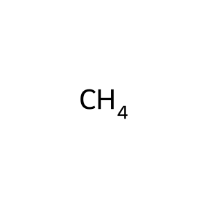

```python
rdkit.Chem.Draw.MolToImage(first_mol)
```

Do you see a contradiction between the MolToImage and GetNumOfAtoms ? Can you explain why below

Because here, we have 1 atom of Carbonne and 4 atoms of Hydrogen, but GetNumOfAtoms consider the molecule like a atom

We will tell rdkit to clone the molecule but to add the hydrogen atoms now. Create a new molecule from first_mol using the method AddHs. Store it in a variable named mol2

```python
mol2 = rdkit.Chem.AddHs(first_mol)
```

Display the number of Atoms now

```python
display(mol2.GetNumAtoms())
```

```
5
```

Display the number of Heavy Atoms (check the methods from dir output)

```python
display(mol2.GetNumHeavyAtoms())
```

```
1
```

Is it coherent ?

Yes, because here we got 5 atoms (C + 4H) and 1 heavy atoms (CH4)

With the MolToImage function of the Draw package, display the molecule mol2.

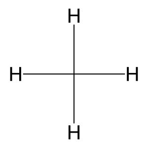

```python
display(rdkit.Chem.Draw.MolToImage(mol2))
```

Let's look at a real molecule now.

The following string contains the SMILE representation of the paracetamol molecule

```python
smile = 'CC(=O)NC1=CC=C(O)C=C1'
```

Using the MolFromSmiles function, create a molecule from the smile representation and print its types

```python
molecule = MolFromSmiles(smile)
print(type(molecule))
```

```
<class 'rdkit.Chem.rdchem.Mol'>
```

With the MolToImage function of the Draw package, display the molecule

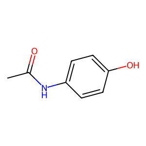

```python
display(rdkit.Chem.Draw.MolToImage(molecule))
```

You can get the Number of atoms of the molecules and the list of atoms with the methods GetNumAtoms and GetAtoms.

Print the number of atoms of the molecule

```python
print(molecule.GetNumAtoms())
print(molecule.GetAtoms())
```

```
11
<rdkit.Chem._GetAtomsIterator object at 0x7a778b720f70>
```

If you compare to the picture, you may see that the number of atoms is not 11. What is the total number and why rdkit do not give the same answer ?

The number of atoms here is 20 (8 carbon, 9 hydrogen, 1 nitrogen and 2 oxygen). RDKIT do not give the same amount of atoms because they don't count Hydrogen atoms.

Print the list of each atoms

```python
for atom in molecule.GetAtoms():
  print(atom.GetSymbol())
```

```
C
C
O
N
C
C
C
C
O
C
C
```

Store the number of bonds of the molecule in **n_bond** (look which method can be used for that) and print

```python
n_bond = molecule.GetNumBonds()
print(n_bond)
```

```
11
```

For each bond, print if the bond is single or double

```python
for bond in molecule.GetBonds():
  if bond.GetBondType() == rdkit.Chem.rdchem.BondType.SINGLE:
    print("Single")
  elif bond.GetBondType() == rdkit.Chem.rdchem.BondType.DOUBLE:
    print("Double")
  else:
    print(bond.GetBondType())
```

```
Single
Double
Single
Single
AROMATIC
AROMATIC
AROMATIC
Single
AROMATIC
AROMATIC
AROMATIC
```

### Reading molecule data from file

Apart SMILES, .SDF and .Mol are also the common formats to save molecules. RDKit provides also functionalities to read these files.

Morphine is an opioid agonist used for the relief of moderate to severe acute and chronic pain. The chemical information of this drug can be found at https://go.drugbank.com/structures/small_molecule_drugs/DB00295.sdf

Download this file and save it in a folder.

```python
!wget https://go.drugbank.com/structures/small_molecule_drugs/DB00295.sdf
```

[output not shown]

SDF files can contain one or more molecules. To load them, you can use SDMolSupplier. When you use it it will return you an object that looks like a list.

Read the file that you've downloaded using "rdkit.Chem.SDMolSupplier" and get the first molecule (the only one) and store it in a variable named **morphine**

```python
morphine = rdkit.Chem.SDMolSupplier("DB00295.sdf")
morphine = morphine[0]
```

Display its type

```python
display(type(morphine))
```

```
rdkit.Chem.rdchem.Mol
```

Display the picture of the molecule

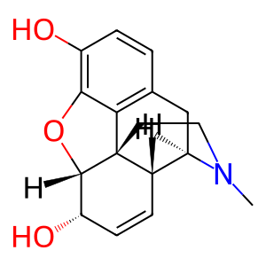

```python
display(rdkit.Chem.Draw.MolToImage(morphine))
```

Display the number of atoms and the number of bonds

```python
display(morphine.GetNumAtoms())
display(morphine.GetNumBonds())
```

```
21
```

```
25
```

### Descriptors

Molecules are also described by a set of physiochemical descriptors like

- the log partition coefficient,
- the polar surface area ... that describe the molecule's structure.

RDKit provides utilities that allow us to compute descriptor of molecules.

The rdkit.Chem.Descriptors module and its sub module let us compute molecule descriptors.

the rdkit.Chem.Descriptors module has an attribute name _descList, display it. It contains a list of tuple. Each tuple has the name of the physical property, and function associated to it to compute the given property

```python
import rdkit.Chem.Descriptors
display(rdkit.Chem.Descriptors._descList)
```

[output not shown]

[output cut: 333 more lines]

[output not shown]

Compute all descriptors in the _descList list of the paracetamol molecule using the MoleculeDescriptors.MolecularDescriptorCalculator class

```python
for descriptor in rdkit.Chem.Descriptors._descList:
  print(descriptor[0], descriptor[1](molecule))
```

```
MaxAbsEStateIndex 10.524468537414966
MaxEStateIndex 10.524468537414966
MinAbsEStateIndex 0.11510204081632636
MinEStateIndex -0.11510204081632636
qed 0.5950261967780849
SPS 9.181818181818182
MolWt 151.165
HeavyAtomMolWt 142.093
ExactMolWt 151.063328528
NumValenceElectrons 58
NumRadicalElectrons 0
MaxPartialCharge 0.22074743631242583
MinPartialCharge -0.5079643157925783
MaxAbsPartialCharge 0.5079643157925783
MinAbsPartialCharge 0.22074743631242583
FpDensityMorgan1 1.3636363636363635
FpDensityMorgan2 1.9090909090909092
FpDensityMorgan3 2.3636363636363638
BCUT2D_MWHI 16.25468871437965
BCUT2D_MWLOW 10.280190859964755
BCUT2D_CHGHI 1.9280360590359866
BCUT2D_CHGLO -1.9945540738765895
BCUT2D_LOGPHI 2.12524757916018
BCUT2D_LOGPLOW -2.04401131261029
BCUT2D_MRHI 5.88095478459792
BCUT2D_MRLOW -0.11373578338266109
AvgIpc 1.9291266251851134
BalabanJ 2.7362980721056545
BertzCT 253.29949758389105
Chi0 8.267584713501616
Chi0n 6.164862962722325
Chi0v 6.164862962722325
Chi1 5.1815405503520555
Chi1n 3.2490981480278296
Chi1v 3.2490981480278296
Chi2n 2.228060242189872
Chi2v 2.228060242189872
Chi3n 1.1876733148984595
Chi3v 1.1876733148984595
Chi4n 0.7480265991539318
```

[output cut: 162 more lines]

```
fr_piperzine 0
fr_priamide 0
fr_prisulfonamd 0
fr_pyridine 0
fr_quatN 0
fr_sulfide 0
fr_sulfonamd 0
fr_sulfone 0
fr_term_acetylene 0
fr_tetrazole 0
fr_thiazole 0
fr_thiocyan 0
fr_thiophene 0
fr_unbrch_alkane 0
fr_urea 0
```

Display the names and the fvalues of the descriptors

```python
display(rdkit.Chem.Descriptors.CalcMolDescriptors(molecule))
```

```
{'MaxAbsEStateIndex': 10.524468537414966,
 'MaxEStateIndex': 10.524468537414966,
 'MinAbsEStateIndex': 0.11510204081632636,
 'MinEStateIndex': -0.11510204081632636,
 'qed': 0.5950261967780849,
 'SPS': 9.181818181818182,
 'MolWt': 151.165,
 'HeavyAtomMolWt': 142.093,
 'ExactMolWt': 151.063328528,
 'NumValenceElectrons': 58,
 'NumRadicalElectrons': 0,
 'MaxPartialCharge': 0.22074743631242583,
 'MinPartialCharge': -0.5079643157925783,
 'MaxAbsPartialCharge': 0.5079643157925783,
 'MinAbsPartialCharge': 0.22074743631242583,
 'FpDensityMorgan1': 1.3636363636363635,
 'FpDensityMorgan2': 1.9090909090909092,
 'FpDensityMorgan3': 2.3636363636363638,
 'BCUT2D_MWHI': 16.25468871437965,
 'BCUT2D_MWLOW': 10.280190859964755,
 'BCUT2D_CHGHI': 1.9280360590359866,
 'BCUT2D_CHGLO': -1.9945540738765895,
 'BCUT2D_LOGPHI': 2.12524757916018,
 'BCUT2D_LOGPLOW': -2.04401131261029,
 'BCUT2D_MRHI': 5.88095478459792,
 'BCUT2D_MRLOW': -0.11373578338266109,
 'AvgIpc': 1.9291266251851134,
 'BalabanJ': 2.7362980721056545,
 'BertzCT': 253.29949758389105,
 'Chi0': 8.267584713501616,
 'Chi0n': 6.164862962722325,
 'Chi0v': 6.164862962722325,
 'Chi1': 5.1815405503520555,
 'Chi1n': 3.2490981480278296,
 'Chi1v': 3.2490981480278296,
 'Chi2n': 2.228060242189872,
 'Chi2v': 2.228060242189872,
 'Chi3n': 1.1876733148984595,
 'Chi3v': 1.1876733148984595,
 'Chi4n': 0.7480265991539318,
```

[output cut: 162 more lines]

```
 'fr_piperzine': 0,
 'fr_priamide': 0,
 'fr_prisulfonamd': 0,
 'fr_pyridine': 0,
 'fr_quatN': 0,
 'fr_sulfide': 0,
 'fr_sulfonamd': 0,
 'fr_sulfone': 0,
 'fr_term_acetylene': 0,
 'fr_tetrazole': 0,
 'fr_thiazole': 0,
 'fr_thiocyan': 0,
 'fr_thiophene': 0,
 'fr_unbrch_alkane': 0,
 'fr_urea': 0}
```

### Fingerprinting

A chemical structure can be characterized by a set of numerical values known as molecular fingerprints. They may be 2D Fragment-based fingerprints presented by bit arrays of 0s and 1s wherein each bit position indicates the presence or absence of structural fragments.

The RDKit has a variety of built-in functionality for generating molecular fingerprints and then using them to calculate molecular similarity. In this exercise, we will generate the fingerprints for parcetamol and aspirin that are two popular drugs used for pains.

```python
gen = rdkit.Chem.MolFromSmiles
aspirin = gen("CC(=O)OC1=CC=CC=C1C(O)=O")
```

With the help of rdkit.Chem.AllChem.GetMorganFingerprintAsBitVect, compute its fingerprint as a bit vector.

```python
from rdkit.Chem import AllChem
fingerprint = rdkit.Chem.AllChem.GetMorganFingerprintAsBitVect(aspirin, 2)
```

```
[00:59:12] DEPRECATION WARNING: please use MorganGenerator
```

Display its type

```python
display(type(fingerprint))
```

```
rdkit.DataStructs.cDataStructs.ExplicitBitVect
```

With the DataStructs module convert it to a numpy vector and display it shape and display it

```python
import numpy as np

conv = np.array([])
rdkit.DataStructs.ConvertToNumpyArray(fingerprint, conv)
display(conv.shape)
display(conv)
```

```
(2048,)
```

```
array([0., 0., 0., ..., 0., 0., 0.])
```

Create a function smiles_to_np_morganfingerprinting which takes a smile representation and gives back the numpy version of the morgan finger_printing

```python
def smiles_to_np_morganfingerprinting(smile):
  mol = rdkit.Chem.MolFromSmiles(smile)
  res = rdkit.Chem.AllChem.GetMorganFingerprintAsBitVect(mol, 2)
  return res
```

Compute the morgan finger printing of the aspirin (CC(=O)OC1=CC=CC=C1C(O)=O) and paracetamol (CC(=O)NC1=CC=C(O)C=C1)

```python
aspi = smiles_to_np_morganfingerprinting("CC(=O)OC1=CC=CC=C1C(O)=O")
para = smiles_to_np_morganfingerprinting("CC(=O)NC1=CC=C(O)C=C1")
```

```
[00:59:12] DEPRECATION WARNING: please use MorganGenerator
[00:59:12] DEPRECATION WARNING: please use MorganGenerator
```

Compute the DiceSimilarity of the two molecules

```python
simi = rdkit.DataStructs.DiceSimilarity(aspi, para)
display(simi)
```

```
0.36363636363636365
```